# Figure S9 Growth rate experiment using Softbugs isolated from *Acromyrmex* ants (resident non-producers)

Douglas Yu

18 May 2020

## Housekeeping

```r
# rm(list=ls())
suppressPackageStartupMessages({
    library(tidyverse)
    library(readxl)
    library(knitr)
    library(RColorBrewer)
    library(ggthemes)
    library(lattice)
    library(lme4)
    library(sjPlot)
    library(envDocument)
    library(conflicted)
})

conflict_prefer("filter", "dplyr", quiet = TRUE)
conflict_prefer("mutate", "dplyr", quiet = TRUE)
conflict_prefer("select", "dplyr", quiet = TRUE)
conflict_prefer("summarise", "dplyr", quiet = TRUE)
conflict_prefer("first", "dplyr", quiet = TRUE)
conflict_prefer("here", "here", quiet = TRUE)
conflict_prefer("separate", "tidyr", quiet = TRUE)
conflict_prefer("unite", "tidyr", quiet = TRUE)
conflict_prefer("intersect", "dplyr", quiet = TRUE)
conflict_prefer("setdiff", "dplyr", quiet = TRUE)
conflict_prefer("expand", "tidyr", quiet = TRUE)
```

```r
datafile <- "Figure_S9_Growth_rate_experiment_DataSheet_20180303.xlsx"
sheet_strepto <- "Streptomyces"
sheet_softbugs <- "softbugs"
```

## Dataset 1: *Streptomyces*

```r
assay1 <- read_excel(datafile, sheet_strepto, na = "NA")
tbl_df(assay1) # should have 540 rows and 10 columns
```

```
## # A tibble: 540 x 10
##    Input.order Ps.strain Ps.genotype Invader Inv.strain Plate Invasion.score
##          <dbl> <chr>     <chr>       <chr>        <dbl> <dbl>          <dbl>
##  1           1 A         Ps2         Strept…          1     1          0.704
##  2           2 A         Ps2         Strept…          1     2          0.694
##  3           3 A         Ps2         Strept…          1     3          0.672
##  4           4 A         Ps2         Strept…          2     1          0.87
##  5           5 A         Ps2         Strept…          2     2          0.874
##  6           6 A         Ps2         Strept…          2     3          1.04
##  7           7 A         Ps2         Strept…          3     1         NA
##  8           8 A         Ps2         Strept…          3     2          0.842
##  9           9 A         Ps2         Strept…          3     3          1.18
## 10          10 A         Ps2         Strept…          5     1          0.676
## # … with 530 more rows, and 3 more variables: Standardised.score <dbl>,
## #   Spore.production <chr>, Notes <chr>
```

```r
assay1 <- assay1 %>% select(-Input.order, -Notes, -Standardised.score, -Spore.production) # should have 540 rows and 6 columns
```

## Dataset 2: Softbugs (our shorthand term for *Non-antibiotic-producers*)

```r
assay2 <- read_excel(datafile, sheet_softbugs, na = "NA")
tbl_df(assay2) # should have 600 rows and 9 cols
```

```
## # A tibble: 600 x 9
##    Input.order Ps.strain Ps.genotype Invader Inv.strain Plate Invasion.score
##          <dbl> <chr>     <chr>       <chr>        <dbl> <dbl>          <dbl>
##  1           1 A         Ps2         soft_b…         11     4          0.577
##  2           2 A         Ps2         soft_b…         11     5          0.409
##  3           3 A         Ps2         soft_b…         11     6          0.464
##  4           4 A         Ps2         soft_b…         12     4          0.601
##  5           5 A         Ps2         soft_b…         12     5          0.462
##  6           6 A         Ps2         soft_b…         12     6          0.728
##  7           7 A         Ps2         soft_b…         13     4          0.408
##  8           8 A         Ps2         soft_b…         13     5          0
##  9           9 A         Ps2         soft_b…         13     6          0.422
## 10          10 A         Ps2         soft_b…         14     4          0.688
## # … with 590 more rows, and 2 more variables: Standardised.score <dbl>,
## #   Notes <chr>
```

```r
assay2 <- assay2 %>% select(-Input.order, -Standardised.score, -Notes) # should have 600 rows and 6 columns
# change plate numbering for consistency
assay2 <- assay2 %>% mutate(Plate = ifelse(Plate == 4, 1, ifelse(Plate == 5, 2, ifelse(Plate == 6, 3, NA))))
```

## Assay 3: Combined

```r
assay3 <- bind_rows(assay1, assay2)
assay3 <- assay3 %>% select(Ps.genotype, Invader, Inv.strain, Ps.strain, Plate, Invasion.score) %>% arrange(Ps.genotype, Invader, Inv.strain, Ps.strain, Plate)
assay3 <- assay3 %>% filter(!is.na(Invasion.score))
assay3$Ps.genotype <- as.factor(assay3$Ps.genotype)
assay3$Invader <- as.factor(assay3$Invader)
assay3$Inv.strain <- as.factor(assay3$Inv.strain)
assay3$Ps.strain <- as.factor(assay3$Ps.strain)
assay3$Plate <- as.factor(assay3$Plate)
tbl_df(assay3) # 1070 rows and 6 cols
```

```
## # A tibble: 1,070 x 6
##    Ps.genotype Invader   Inv.strain Ps.strain Plate Invasion.score
##    <fct>       <fct>     <fct>      <fct>     <fct>          <dbl>
##  1 Control     soft_bugs 11         Control   1              0.581
##  2 Control     soft_bugs 11         Control   2              0.645
##  3 Control     soft_bugs 11         Control   3              0.777
##  4 Control     soft_bugs 12         Control   1              0.697
##  5 Control     soft_bugs 12         Control   2              0.77
##  6 Control     soft_bugs 12         Control   3              0.593
##  7 Control     soft_bugs 13         Control   1              0.478
##  8 Control     soft_bugs 13         Control   2              0.64
##  9 Control     soft_bugs 13         Control   3              0.723
## 10 Control     soft_bugs 14         Control   1              0.532
## # … with 1,060 more rows
```

Create crosstabs to see experimental design

```r
assay4 <- assay3 %>% filter(Ps.strain != "Control")
assay4$Ps.strain <- droplevels(assay4$Ps.strain)
xtabs(~ Inv.strain + Ps.strain + Plate, assay4)
```

```
## , , Plate = 1
##
##           Ps.strain
## Inv.strain A B C D E F G H I J K L M N Ø P Q R S
##         1  1 1 1 1 1 1 0 1 0 1 1 1 1 1 1 1 1 0 1
##         2  1 1 1 1 1 1 0 1 0 1 1 1 1 1 1 1 1 0 1
##         3  0 1 1 1 1 1 0 1 0 1 1 1 1 1 1 1 1 0 1
##         5  1 1 1 1 1 1 0 1 0 1 1 1 1 1 1 1 1 0 1
##         6  1 1 1 1 1 1 0 1 0 1 1 1 1 1 1 1 1 0 1
##         7  1 1 1 1 1 1 0 1 0 1 1 1 1 1 1 1 1 0 1
##         8  1 1 1 1 1 1 0 1 0 1 1 1 1 1 1 1 1 0 1
##         9  1 1 1 1 1 1 0 1 0 1 1 1 1 1 1 1 1 0 1
##         10 1 1 1 1 1 1 0 1 0 1 1 1 1 1 1 1 1 0 1
##         11 1 1 1 1 1 1 0 1 1 1 1 1 1 1 1 1 1 1 1
##         12 1 1 1 1 1 1 0 1 1 1 1 1 1 1 1 1 1 1 1
```

[output cut: 56 more lines]

```r
rm(assay4)

assay5 <- assay3 %>% filter(Ps.strain == "Control")
assay5$Ps.strain <- droplevels(assay5$Ps.strain)
xtabs(~ Inv.strain + Ps.strain + Plate, assay5)
```

```
## , , Plate = 1
##
##           Ps.strain
## Inv.strain Control
##         1        1
##         2        1
##         3        1
##         5        1
##         6        1
##         7        1
##         8        1
##         9        1
##         10       1
##         11       1
##         12       1
```

[output cut: 56 more lines]

```r
rm(assay5)
```

sample sizes

```r
assay1 %>% count(Invader, Ps.genotype)
```

```
## # A tibble: 3 x 3
##   Invader      Ps.genotype     n
##   <chr>        <chr>       <int>
## 1 Streptomyces Control        27
## 2 Streptomyces Ps1           216
## 3 Streptomyces Ps2           297
```

```r
assay2 %>% count(Invader, Ps.genotype)
```

```
## # A tibble: 3 x 3
##   Invader   Ps.genotype     n
##   <chr>     <chr>       <int>
## 1 soft_bugs Control        30
## 2 soft_bugs Ps1           240
## 3 soft_bugs Ps2           330
```

```r
assay3 %>% count(Invader, Ps.genotype)
```

```
## # A tibble: 6 x 3
##   Invader      Ps.genotype     n
##   <fct>        <fct>       <int>
## 1 soft_bugs    Control        30
## 2 soft_bugs    Ps1           240
## 3 soft_bugs    Ps2           310
## 4 Streptomyces Control        27
## 5 Streptomyces Ps1           207
## 6 Streptomyces Ps2           256
```

To read these tables:

1. We infused the media with metabolites from 19 *Pseudonocardia* lines that had been collected from 19 different ant colonies (A-S), plus a non-infused control media. There are potentially genetic differences among these vertically transmitted lineages, so we call them: Ps.strain
2. We measured growth rates of 9 strains of *Streptomyces* (1,2,3,5,6,7,8,9,10) and 10 strains of Softbugs (11-20). These are potential invading strains on attine cuticles so we call them: Inv.strain.
3. Each (19 * 19 =) 361 combinations of Ps.strain and Inv.strain was repeated 3 times for a total sample size of (361 * 3=) 1083 treatment inoculations (19 * 9 * 3 *Streptomyces* inoculations = 513; 19 * 10 * 3 = 570 Softbug inoculations), but some colonies could not be scored due to difficulties in reading colony area, leaving us with (207 + 256 =) 463 *Streptomyces* inoculations and (240 + 310 =) 550 Softbug inoculations 463 + 550 = 1013 treatment inoculations + (27 + 30 =) 57 Control inoculations = 1070 total inoculations
4. Thus, the experiment is fully crossed but somewhat imbalanced at the end.
5. (513 - 463 =) 50 *Streptomyces* inoculations and (570 - 550) = 20 Softbug inoculations could not be scored.

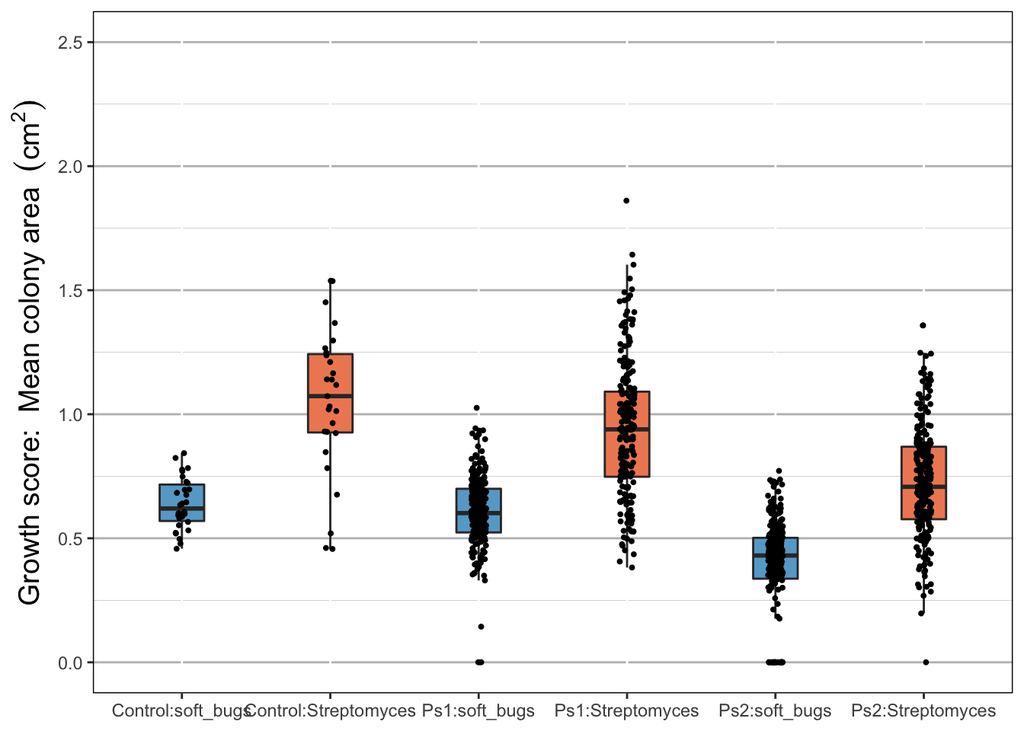

```r
colorvec <- brewer.pal(3,"RdBu")
colorvec <- c(colorvec[3], colorvec[1], colorvec[2])

p <- ggplot(assay3, aes(x = Ps.genotype:Invader, y = Invasion.score))

(q <- p + ylim(0, 2.5) # to have same y-range as Figure 1A
    + geom_boxplot(size = .5, outlier.shape = NA, width = 0.3, aes(fill = Invader))
    + geom_jitter(width = 0.05, cex = 0.7)
    + scale_shape_manual(values = c(16, 2))
    + labs(y = expression("Growth score:  Mean colony area " ~ (cm^{2})))
    # + scale_fill_brewer(type = "qual", palette = "Set3") # alternative color set
    + scale_fill_manual(values = colorvec)
    + theme(axis.title.y = element_text(size = 14),
            axis.title.x = element_blank(),
            legend.position='none',
            panel.background = element_rect(fill = "white"),
            panel.grid.major.y = element_line(colour = "grey", size = 0.5),
            panel.grid.minor.y = element_line(colour = "grey", size = 0.1),
            panel.border = element_rect(colour = "black", fill = NA)
            )
    )
```

To read these boxplots:

The y-axis is the final area (cm<sup>2</sup>) of the colony inoculated onto the plate (the notional ‘invader’)

1. *Streptomyces* colonies are generally bigger than non-producer colonies (i.e. *Streptomyces* are faster growers) on all media: control and *Pseudonocardia*-infused.
2. The 19 *Pseudonocardia* colonies (Ps.strain) used to infuse the media can be usefully divided into two 16S genotypes (Ps1 n = 8, Ps2 n = 11). Growth rates of *Streptomyces* and ‘soft_bugs’ appear lower on the Ps2 infusions (i.e. Ps2 appears to be a more effective inhibitor in general).
3. There are fewer Control datapoints because this represents only one kind of media, whereas the *Pseudonocardia* (Ps1 and Ps2) treatments represent 19 colonies.

## Start of analysis.

There are two potential random factors:

1. *Pseudonocardia* strains: `Ps.strain` (19 levels: A-S)
2. Invader strains: `Inv.strain` (19 levels: numbered 1-20, but no strain 4). 1-10 are *Streptomyces* strains (no strain 4), 11-20 are Softbug strains

There are 3 Plate replicates for each combination of Ps.strain and Inv.strain, and each of the 19 Inv.strains is tested against each Ps.strain. Some complexity: not all inoculations were scorable, so were omitted, and there is no strain 4 in the *Streptomyces*. This is a fully crossed but somewhat imbalanced experiment

There are 2 fixed factors:

1. Pseuonocardia genotype: `Ps.genotype` (Ps1, Ps2).
2. Invader type: `Invader` (softbugs, *Streptomyces*)

Finally, the response variable is:

1. Mean colony area (cm<sup>2</sup>): `Invasion.score`

Construct a full model and test for correlated residuals in each of the potential random factors

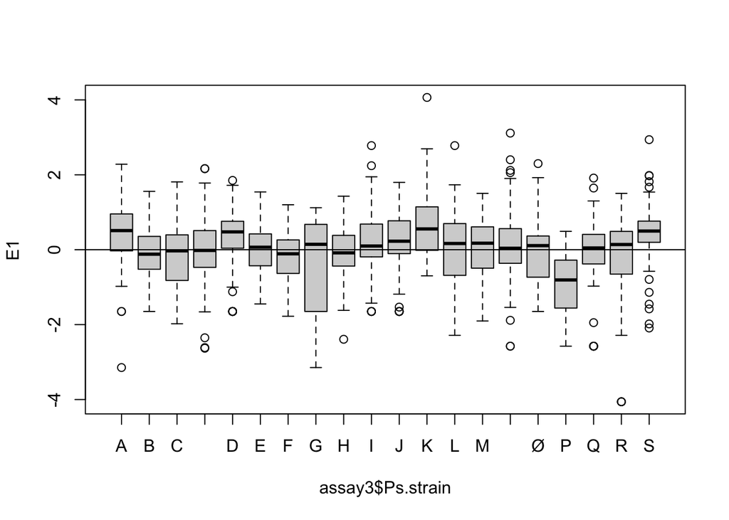

```r
M1 <- lm(Invasion.score~Invader*Ps.genotype, data=assay3)
E1 <- rstandard(M1)
plot(E1 ~ assay3$Ps.strain); abline(0,0) # A,D,K,P,S strains either mostly above or below 0, demonstrating correlated residuals for some strains
```

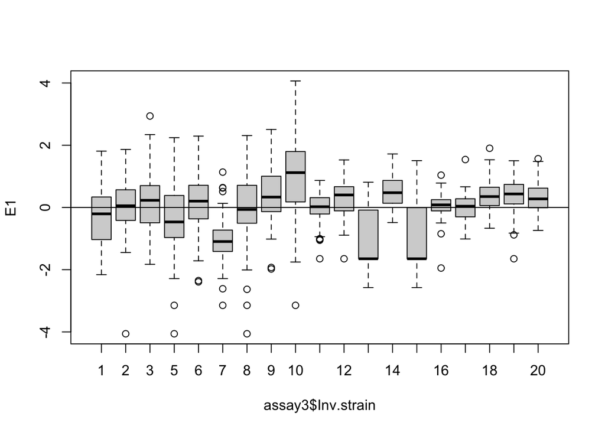

```r
plot(E1 ~ assay3$Inv.strain); abline(0,0) # 7,10,13,15,18,19,20 either mostly above or below 0, demonstrating correlated residuals for some strains
```

```r
rm(M1)
rm(E1)
```

Thus, we use a model with random factors

```r
# with interaction effect
M1 <- lmer(Invasion.score ~ Invader * Ps.genotype + (1|Ps.strain/Plate) + (1|Inv.strain), data=assay3, REML = FALSE)
# without interaction effect
M2 <- lmer(Invasion.score ~ Invader + Ps.genotype + (1|Ps.strain/Plate) + (1|Inv.strain), data=assay3, REML = FALSE)

anova(M1, M2) # no significant interaction effect:  p = 0.2672
```

```
## Data: assay3
## Models:
## M2: Invasion.score ~ Invader + Ps.genotype + (1 | Ps.strain/Plate) +
## M2:     (1 | Inv.strain)
## M1: Invasion.score ~ Invader * Ps.genotype + (1 | Ps.strain/Plate) +
## M1:     (1 | Inv.strain)
##    npar     AIC     BIC logLik deviance  Chisq Df Pr(>Chisq)
## M2    8 -560.73 -520.93 288.37  -576.73
## M1   10 -559.37 -509.62 289.69  -579.37 2.6394  2     0.2672
```

```r
AIC(M1, M2) # AIC difference < 2, and anyway the model with the interaction effect (M1) has a slightly higher AIC
```

```
##    df       AIC
## M1 10 -559.3702
## M2  8 -560.7307
```

Not surprisingly, there is no interaction effect

Random factors:

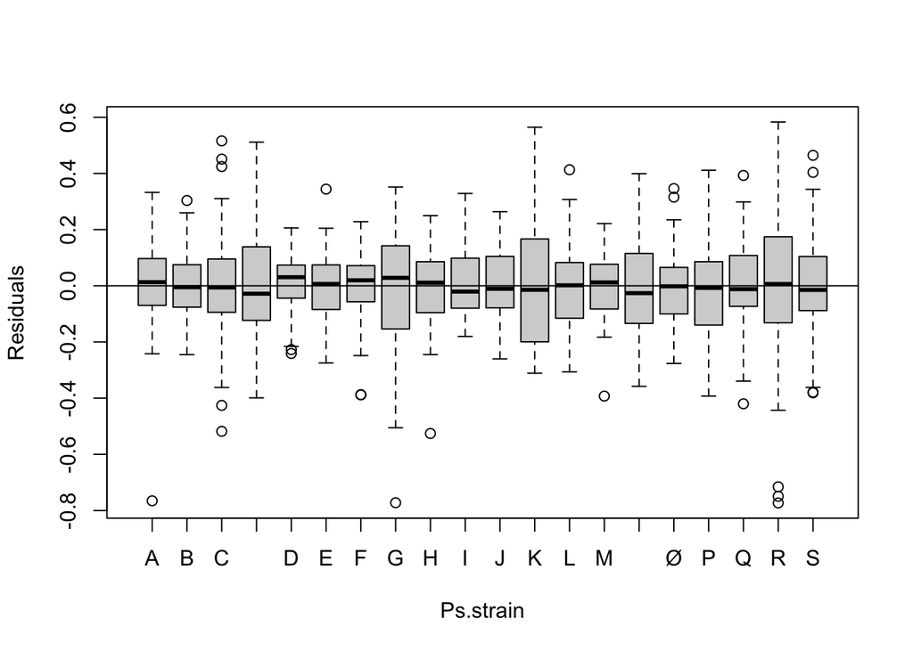

```r
plot(assay3$Ps.strain, resid(M2), xlab="Ps.strain", ylab="Residuals"); abline(0,0)
```

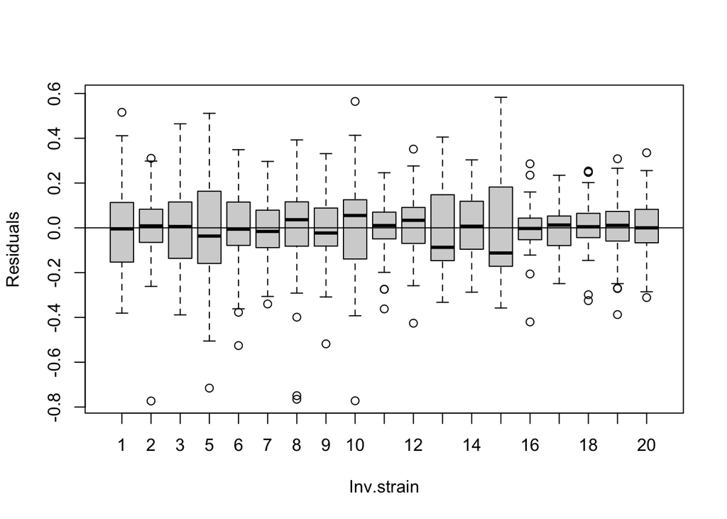

```r
plot(assay3$Inv.strain, resid(M2), xlab="Inv.strain", ylab="Residuals"); abline(0,0)
```

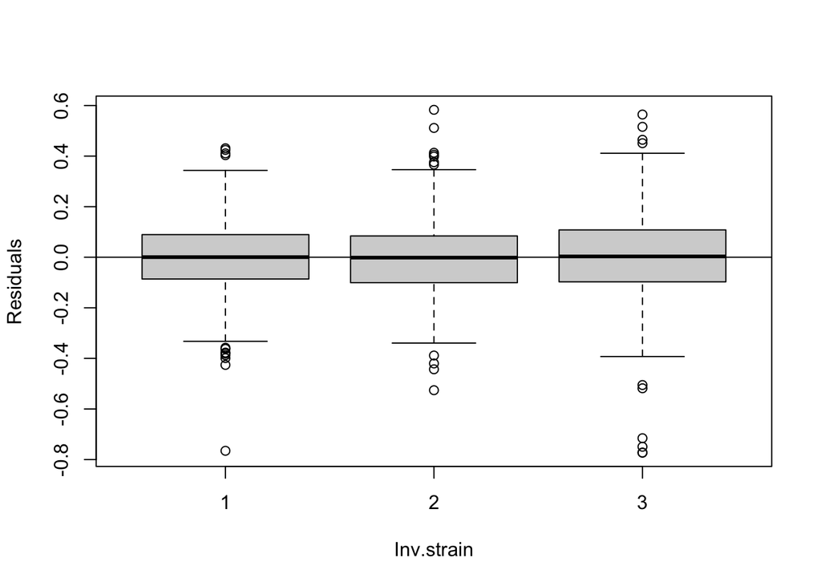

```r
plot(assay3$Plate, resid(M2), xlab="Inv.strain", ylab="Residuals"); abline(0,0)
```

The corelated residuals have gone away, as expected.

Now we test for the two main effects

```r
M3 <- lmer(Invasion.score ~ Invader  + (1|Ps.strain/Plate) + (1|Inv.strain), data=assay3, REML = FALSE)

M4 <- lmer(Invasion.score ~ Ps.genotype + (1|Ps.strain/Plate) + (1|Inv.strain), data=assay3, REML = FALSE)

summary(M2) # model with both main effects
```

```
## Linear mixed model fit by maximum likelihood  ['lmerMod']
## Formula: Invasion.score ~ Invader + Ps.genotype + (1 | Ps.strain/Plate) +
##     (1 | Inv.strain)
##    Data: assay3
##
##      AIC      BIC   logLik deviance df.resid
##   -560.7   -520.9    288.4   -576.7     1062
##
## Scaled residuals:
##     Min      1Q  Median      3Q     Max
## -4.5373 -0.5692  0.0024  0.5424  3.4217
##
## Random effects:
##  Groups          Name        Variance Std.Dev.
##  Plate:Ps.strain (Intercept) 0.006768 0.08227
##  Ps.strain       (Intercept) 0.003428 0.05855
##  Inv.strain      (Intercept) 0.013969 0.11819
##  Residual                    0.029026 0.17037
## Number of obs: 1070, groups:
## Plate:Ps.strain, 59; Ps.strain, 20; Inv.strain, 19
##
## Fixed effects:
##                     Estimate Std. Error t value
## (Intercept)          0.67111    0.08727   7.690
## InvaderStreptomyces  0.34244    0.05533   6.189
## Ps.genotypePs1      -0.08047    0.08348  -0.964
## Ps.genotypePs2      -0.29020    0.08229  -3.527
##
## Correlation of Fixed Effects:
##             (Intr) InvdrS Ps.gP1
## InvdrStrptm -0.300
## Ps.gntypPs1 -0.850  0.000
## Ps.gntypPs2 -0.863  0.001  0.902
```

```r
anova(M2, M3)
```

```
## Data: assay3
## Models:
## M3: Invasion.score ~ Invader + (1 | Ps.strain/Plate) + (1 | Inv.strain)
## M2: Invasion.score ~ Invader + Ps.genotype + (1 | Ps.strain/Plate) +
## M2:     (1 | Inv.strain)
##    npar     AIC     BIC logLik deviance  Chisq Df Pr(>Chisq)
## M3    6 -543.30 -513.45 277.65  -555.30
## M2    8 -560.73 -520.93 288.37  -576.73 21.429  2  2.222e-05 ***
## ---
## Signif. codes:  0 '***' 0.001 '**' 0.01 '*' 0.05 '.' 0.1 ' ' 1
```

```r
anova(M2, M4)
```

```
## Data: assay3
## Models:
## M4: Invasion.score ~ Ps.genotype + (1 | Ps.strain/Plate) + (1 | Inv.strain)
## M2: Invasion.score ~ Invader + Ps.genotype + (1 | Ps.strain/Plate) +
## M2:     (1 | Inv.strain)
##    npar     AIC     BIC logLik deviance  Chisq Df Pr(>Chisq)
## M4    7 -541.77 -506.94 277.88  -555.77
## M2    8 -560.73 -520.93 288.37  -576.73 20.964  1   4.68e-06 ***
## ---
## Signif. codes:  0 '***' 0.001 '**' 0.01 '*' 0.05 '.' 0.1 ' ' 1
```

```r
AIC(M2, M3)
```

```
##    df       AIC
## M2  8 -560.7307
## M3  6 -543.3014
```

```r
AIC(M2, M4)
```

```
##    df       AIC
## M2  8 -560.7307
## M4  7 -541.7669
```

Both main effects are highly significant and have much lower AICs, so we keep both.

Now estimate parameter values

```r
M2 <- lmer(Invasion.score ~ Invader + Ps.genotype + (1|Ps.strain/Plate) + (1|Inv.strain), data=assay3, REML = TRUE)
summary(M2)
```

```
## Linear mixed model fit by REML ['lmerMod']
## Formula: Invasion.score ~ Invader + Ps.genotype + (1 | Ps.strain/Plate) +
##     (1 | Inv.strain)
##    Data: assay3
##
## REML criterion at convergence: -560
##
## Scaled residuals:
##     Min      1Q  Median      3Q     Max
## -4.5350 -0.5652 -0.0008  0.5410  3.4280
##
## Random effects:
##  Groups          Name        Variance Std.Dev.
##  Plate:Ps.strain (Intercept) 0.006763 0.08224
##  Ps.strain       (Intercept) 0.004285 0.06546
##  Inv.strain      (Intercept) 0.015440 0.12426
##  Residual                    0.029026 0.17037
## Number of obs: 1070, groups:
## Plate:Ps.strain, 59; Ps.strain, 20; Inv.strain, 19
##
## Fixed effects:
##                     Estimate Std. Error t value
## (Intercept)          0.67113    0.09283   7.230
## InvaderStreptomyces  0.34240    0.05807   5.896
## Ps.genotypePs1      -0.08048    0.08906  -0.904
## Ps.genotypePs2      -0.29034    0.08778  -3.308
##
## Correlation of Fixed Effects:
##             (Intr) InvdrS Ps.gP1
## InvdrStrptm -0.296
## Ps.gntypPs1 -0.853  0.000
## Ps.gntypPs2 -0.865  0.001  0.902
```

*Streptomyces* grow more quickly than do the Softbugs (0.34240), and there is a growth-rate difference amongst the three media levels: Control, Ps1-infused, Ps2-infused. By eye and parameter value, it looks like the significant media effect is caused by Ps2, which we can test post-hoc.

Remove the Control level and test again for a significant effect of Ps.genotype

```r
assay4 <- assay3 %>% filter(Ps.genotype != "Control")
assay4$Ps.genotype <- fct_drop(assay4$Ps.genotype)

M5 <- lmer(Invasion.score ~ Invader + Ps.genotype + (1|Ps.strain/Plate) + (1|Inv.strain), data=assay4, REML = FALSE)
M6 <- lmer(Invasion.score ~ Invader + (1|Ps.strain/Plate) + (1|Inv.strain), data=assay4, REML = FALSE)

anova(M5, M6)
```

```
## Data: assay4
## Models:
## M6: Invasion.score ~ Invader + (1 | Ps.strain/Plate) + (1 | Inv.strain)
## M5: Invasion.score ~ Invader + Ps.genotype + (1 | Ps.strain/Plate) +
## M5:     (1 | Inv.strain)
##    npar     AIC     BIC logLik deviance  Chisq Df Pr(>Chisq)
## M6    6 -539.17 -509.64 275.58  -551.17
## M5    7 -555.39 -520.95 284.70  -569.39 18.224  1  1.963e-05 ***
## ---
## Signif. codes:  0 '***' 0.001 '**' 0.01 '*' 0.05 '.' 0.1 ' ' 1
```

Ps.genoptype remains highly significant. Growth is different between the Ps1 and Ps2-infused media

Now estimate parameter value

```r
M7 <- lmer(Invasion.score ~ Invader + Ps.genotype + (1|Ps.strain/Plate) + (1|Inv.strain), data=assay4, REML = TRUE)
summary(M7)
```

```
## Linear mixed model fit by REML ['lmerMod']
## Formula: Invasion.score ~ Invader + Ps.genotype + (1 | Ps.strain/Plate) +
##     (1 | Inv.strain)
##    Data: assay4
##
## REML criterion at convergence: -556
##
## Scaled residuals:
##     Min      1Q  Median      3Q     Max
## -4.6383 -0.5625 -0.0017  0.5324  3.5662
##
## Random effects:
##  Groups          Name        Variance Std.Dev.
##  Plate:Ps.strain (Intercept) 0.006072 0.07792
##  Ps.strain       (Intercept) 0.004547 0.06743
##  Inv.strain      (Intercept) 0.016764 0.12948
##  Residual                    0.028267 0.16813
## Number of obs: 1013, groups:
## Plate:Ps.strain, 56; Ps.strain, 19; Inv.strain, 19
##
## Fixed effects:
##                     Estimate Std. Error t value
## (Intercept)          0.59240    0.05085  11.650
## InvaderStreptomyces  0.33841    0.06046   5.597
## Ps.genotypePs2      -0.21004    0.03928  -5.348
##
## Correlation of Fixed Effects:
##             (Intr) InvdrS
## InvdrStrptm -0.563
## Ps.gntypPs2 -0.444  0.001
```

Growth rate is lower on Ps2 (-0.21004).

**Reproducibility receipt**

```r
# datetime
Sys.time()
```

```
## [1] "2020-11-19 10:18:33 GMT"
```

```r
# repository
git2r::repository(here::here())
```

```
## Local:    main /Users/Negorashi2011/Dropbox/Working_docs/Hutchings/Worsley_Ant_SIP-RNA/For_submssion/manuscript/Supplementary_information/R_code_data
## Remote:   main @ origin (https://github.com/dougwyu/Worsley_et_al_screening_test_R_code.git)
## Head:     [81e3913] 2020-10-04: Update README.md
```

```r
envDocument::env_doc("table", git = FALSE)
```

```
##
##
## Table: System Information
##
## |Name           |Value                                                                                                                                  |
## |:--------------|:--------------------------------------------------------------------------------------------------------------------------------------|
## |sysname        |Darwin                                                                                                                                 |
## |release        |19.6.0                                                                                                                                 |
## |version        |Darwin Kernel Version 19.6.0: Thu Oct 29 22:56:45 PDT 2020; root:xnu-6153.141.2.2~1/RELEASE_X86_64                                     |
## |nodename       |Douglas-Yu-MBP                                                                                                                         |
## |machine        |x86_64                                                                                                                                 |
## |login          |root                                                                                                                                   |
## |user           |Negorashi2011                                                                                                                          |
## |effective_user |Negorashi2011                                                                                                                          |
## |Directory      |/Users/Negorashi2011/Dropbox/Working_docs/Hutchings/Worsley_Ant_SIP-RNA/For_submssion/manuscript/Supplementary_information/R_code_data |
##
##
## Table: R Information
##
## |Name    |Value                        |
## |:-------|:----------------------------|
## |Version |R version 4.0.3 (2020-10-10) |
##
##
## Table: Packages Information
##
## |Name         |Value                                     |
## |:------------|:-----------------------------------------|
## |conflicted   |1.0.4 CRAN CRAN 2019-06-21 22:40:03 UTC   |
## |envDocument  |2.4.1 CRAN CRAN 2019-08-08                |
## |sjPlot       |2.8.6 CRAN CRAN 2020-10-28 21:40:02 UTC   |
## |lme4         |1.1-25 CRAN CRAN 2020-10-23 08:20:07 UTC  |
## |Matrix       |1.2-18 CRAN CRAN 2019-11-25               |
## |lattice      |0.20-41 CRAN CRAN 2020-04-01              |
## |ggthemes     |4.2.0 CRAN CRAN 2019-05-13 09:10:03 UTC   |
## |RColorBrewer |1.1-2 CRAN CRAN 2014-12-07                |
## |knitr        |1.30 CRAN CRAN 2020-09-22 16:30:03 UTC    |
## |readxl       |1.3.1 CRAN CRAN 2019-03-13 16:30:02 UTC   |
## |forcats      |0.5.0 CRAN CRAN 2020-03-01 18:10:02 UTC   |
## |stringr      |1.4.0 CRAN CRAN 2019-02-10 03:40:03 UTC   |
```

[output cut: 81 more lines]

```
## |coda         |0.19-4 CRAN CRAN 2020-09-30               |
## |survival     |3.2-7 CRAN CRAN 2020-09-24                |
## |memoise      |1.1.0 CRAN CRAN 2017-04-21 05:54:22 UTC   |
## |statmod      |1.4.35 CRAN CRAN 2020-10-18               |
## |TH.data      |1.0-10 CRAN CRAN 2019-01-22               |
## |ellipsis     |0.3.1 CRAN CRAN 2020-05-15 14:10:06 UTC   |
## |here         |1.0.0 CRAN CRAN 2020-11-15                |
##
##
## Table: Script Information
##
## |Name     |Value                                                                                                                                                                       |
## |:--------|:---------------------------------------------------------------------------------------------------------------------------------------------------------------------------|
## |Path     |/Users/Negorashi2011/Dropbox/Working_docs/Hutchings/Worsley_Ant_SIP-RNA/For_submssion/manuscript/Supplementary_information/R_code_data/Figure_S9_Growth_rate_experiment.Rmd |
## |Modified |2020-11-19 10:18:13                                                                                                                                                         |
```